# Advanced Statistics in EdgeR

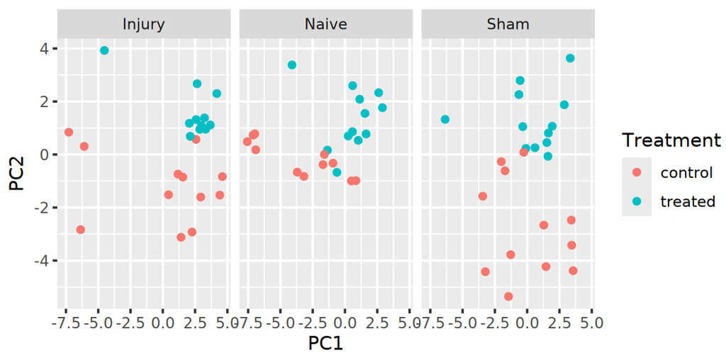

```r
ggplot(pca.data, aes(x=PC1, y=PC2, color=Treatment)) + geom_point() +
   facet_grid(~Injury)
```

### 3.5.11 Plot each factor, add confidence ellipse

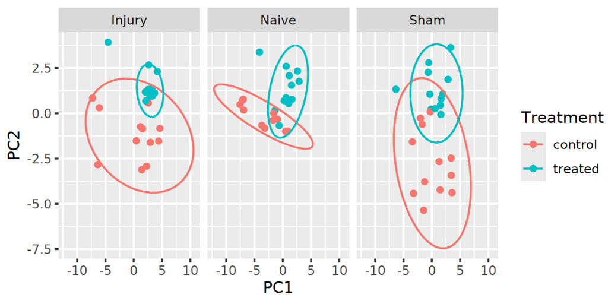

```r
ggplot(pca.data, aes(x=PC1, y=PC2, color=Treatment)) + geom_point() +
  facet_grid(~Injury) + stat_ellipse()
```

### 3.5.12 Add counts for Bacteroidetes and Firmicutes

The Firmicutes/Bacteroidetes ratio is a common measure of the health of a gut microbiome. We can add that value to the PCA plot as the dot colors.

```r
pca.data.expanded <- cbind(pca.data,
   Bacteroidetes = t(data["Bacteroidetes",]),
   Firmicutes = t(data["Firmicutes",]))
```

### 3.5.13 Plot colored by Firmicutes/Bacteriodetes ratio

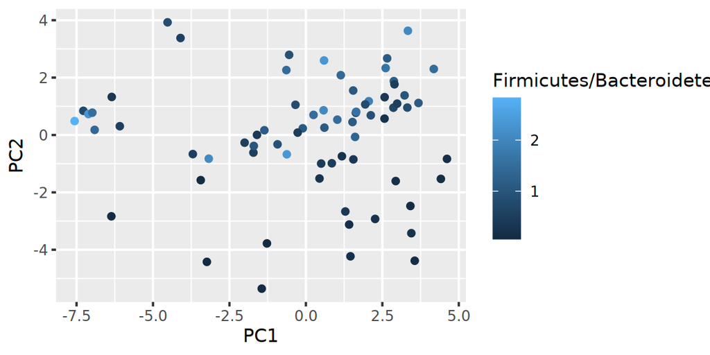

```r
ggplot(pca.data.expanded, aes(x=PC1, y=PC2, color=Firmicutes / Bacteroidetes)) +
   geom_point()
```

### 3.5.14 Plot colored by the log2-ratio

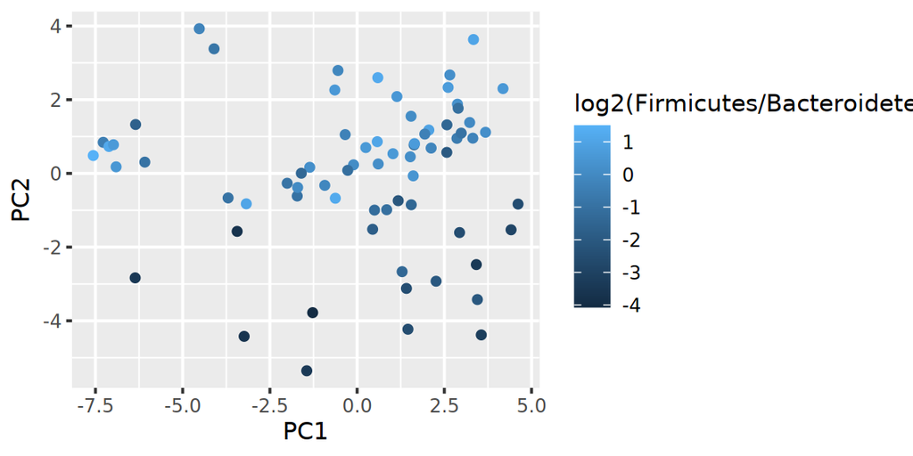

```r
ggplot(pca.data.expanded, aes(x=PC1, y=PC2, color=log2(Firmicutes / Bacteroidetes))) +
  geom_point()
```

### 3.5.15 Make a biplot

This allows us to visualize the contribution of each feature on the principle components. Note that you may want to be careful with this plot if you have a huge number of features, but with a relatively small number of taxa it will work.

First, get the rotation matrix as a data frame.

```r
rotation <- data.frame(taxa=rownames(pca$rotation), pca$rotation)
```

Next determine a scalar to multiply the vector lengths by so that the scales line correctly.

```r
mult.pc1 <- max(pca.data[, "PC1"]) - min(pca.data[, "PC1"]) /
           (max(rotation[, "PC1"]) - min(rotation[, "PC1"]))
mult.pc2 <- max(pca.data[, "PC2"]) - min(pca.data[, "PC2"]) /
           (max(rotation[, "PC2"]) - min(rotation[, "PC2"]))
mult <- min(mult.pc1, mult.pc2)
rotation$PC1 = mult * rotation$PC1
rotation$PC2 = mult * rotation$PC2
```

Start creating the plot of the PCA data colored by treatment. We will separate this into multiple lines to demonstrate how you can add plot components together.

```r
plot <- ggplot(pca.data, aes(x=PC1, y=PC2, color=Treatment)) + geom_point()
```

Add vertical and horizontal lines for the middle of the biplot using geom_hline() and geom_vline() methods.

```r
plot <- plot + geom_hline(yintercept=0) + geom_vline(xintercept=0)
```

Add text labels for each taxa. Set clip=“off” to let text labels go outside the plot area.

```r
plot <- plot + geom_text(data=rotation, aes(x=PC1, y=PC2, label=taxa),
       size=3, hjust=0, vjust=0, color="red") + coord_equal(clip='off')
```

Add arrows for the biplot: from the origin (0,0) to the PC coordinate in the rotation matrix.

```r
plot <- plot + geom_segment(data=rotation, aes(x=0, y=0, xend=PC1, yend=PC2),
   arrow=arrow(length=unit(0.2, "cm")), color="red")
```

Finally, print out the plot.

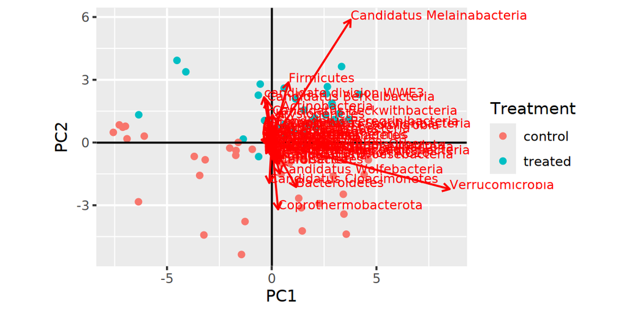

```r
plot
```